# Risk Factor Analysis

## Outcome Variable

**Outcome Variable:** haz

## Predictor Variables

**Intervention Variable:** predfeed6

**Adjustment Set:**

- arm
- sex
- month
- brthmon
- W_mage
- meducyrs
- feducyrs
- hhwealth_quart
- hfoodsec
- W_mhtcm
- vagbrth
- W_gagebrth
- W_birthwt
- W_birthlen
- W_nrooms
- W_nchldlt5
- W_parity
- impfloor
- impsan
- safeh20
- delta_W_mage
- delta_meducyrs
- delta_feducyrs
- delta_hhwealth_quart
- delta_hfoodsec
- delta_W_mhtcm
- delta_vagbrth
- delta_W_gagebrth
- delta_W_birthwt
- delta_W_birthlen
- delta_W_nrooms
- delta_W_nchldlt5
- delta_W_parity
- delta_impfloor
- delta_impsan
- delta_safeh20

## Stratifying Variables

The analysis was stratified on these variable(s):

- agecat
- studyid
- country

## Data Summary

| agecat | studyid | country | predfeed6 | n_cell | n |
| --- | --- | --- | --- | --- | --- |
| Birth | ki0047075b-MAL-ED | BANGLADESH | 1 | 119 | 231 |
| Birth | ki0047075b-MAL-ED | BANGLADESH | 0 | 112 | 231 |
| Birth | ki0047075b-MAL-ED | BRAZIL | 1 | 27 | 175 |
| Birth | ki0047075b-MAL-ED | BRAZIL | 0 | 148 | 175 |
| Birth | ki0047075b-MAL-ED | INDIA | 1 | 15 | 190 |
| Birth | ki0047075b-MAL-ED | INDIA | 0 | 175 | 190 |
| Birth | ki0047075b-MAL-ED | NEPAL | 1 | 23 | 170 |
| Birth | ki0047075b-MAL-ED | NEPAL | 0 | 147 | 170 |
| Birth | ki0047075b-MAL-ED | PERU | 1 | 106 | 256 |
| Birth | ki0047075b-MAL-ED | PERU | 0 | 150 | 256 |
| Birth | ki0047075b-MAL-ED | SOUTH AFRICA | 1 | 3 | 211 |
| Birth | ki0047075b-MAL-ED | SOUTH AFRICA | 0 | 208 | 211 |
| Birth | ki0047075b-MAL-ED | TANZANIA, UNITED REPUBLIC OF | 1 | 1 | 119 |
| Birth | ki0047075b-MAL-ED | TANZANIA, UNITED REPUBLIC OF | 0 | 118 | 119 |
| Birth | ki1000109-EE | PAKISTAN | 1 | 1 | 2 |
| Birth | ki1000109-EE | PAKISTAN | 0 | 1 | 2 |
| Birth | kiGH5241-JiVitA-3 | BANGLADESH | 1 | 15096 | 19082 |
| Birth | kiGH5241-JiVitA-3 | BANGLADESH | 0 | 3986 | 19082 |
| Birth | kiGH5241-JiVitA-4 | BANGLADESH | 1 | 619 | 767 |
| Birth | kiGH5241-JiVitA-4 | BANGLADESH | 0 | 148 | 767 |
| 6 months | ki0047075b-MAL-ED | BANGLADESH | 1 | 123 | 235 |
| 6 months | ki0047075b-MAL-ED | BANGLADESH | 0 | 112 | 235 |
| 6 months | ki0047075b-MAL-ED | BRAZIL | 1 | 35 | 209 |
| 6 months | ki0047075b-MAL-ED | BRAZIL | 0 | 174 | 209 |
| 6 months | ki0047075b-MAL-ED | INDIA | 1 | 18 | 232 |
| 6 months | ki0047075b-MAL-ED | INDIA | 0 | 214 | 232 |
| 6 months | ki0047075b-MAL-ED | NEPAL | 1 | 29 | 235 |
| 6 months | ki0047075b-MAL-ED | NEPAL | 0 | 206 | 235 |
| 6 months | ki0047075b-MAL-ED | PERU | 1 | 113 | 269 |
| 6 months | ki0047075b-MAL-ED | PERU | 0 | 156 | 269 |
| 6 months | ki0047075b-MAL-ED | SOUTH AFRICA | 1 | 3 | 242 |
| 6 months | ki0047075b-MAL-ED | SOUTH AFRICA | 0 | 239 | 242 |
| 6 months | ki0047075b-MAL-ED | TANZANIA, UNITED REPUBLIC OF | 1 | 2 | 244 |
| 6 months | ki0047075b-MAL-ED | TANZANIA, UNITED REPUBLIC OF | 0 | 242 | 244 |
| 6 months | ki1000109-EE | PAKISTAN | 1 | 218 | 372 |
| 6 months | ki1000109-EE | PAKISTAN | 0 | 154 | 372 |
| 6 months | ki1000304b-SAS-FoodSuppl | INDIA | 1 | 0 | 168 |
| 6 months | ki1000304b-SAS-FoodSuppl | INDIA | 0 | 168 | 168 |
| 6 months | ki1113344-GMS-Nepal | NEPAL | 1 | 404 | 546 |
| 6 months | ki1113344-GMS-Nepal | NEPAL | 0 | 142 | 546 |
| 6 months | ki1148112-LCNI-5 | MALAWI | 1 | 47 | 272 |
| 6 months | ki1148112-LCNI-5 | MALAWI | 0 | 225 | 272 |
| 6 months | kiGH5241-JiVitA-3 | BANGLADESH | 1 | 13223 | 16682 |
| 6 months | kiGH5241-JiVitA-3 | BANGLADESH | 0 | 3459 | 16682 |
| 6 months | kiGH5241-JiVitA-4 | BANGLADESH | 1 | 3332 | 4259 |
| 6 months | kiGH5241-JiVitA-4 | BANGLADESH | 0 | 927 | 4259 |
| 24 months | ki0047075b-MAL-ED | BANGLADESH | 1 | 112 | 209 |
| 24 months | ki0047075b-MAL-ED | BANGLADESH | 0 | 97 | 209 |
| 24 months | ki0047075b-MAL-ED | BRAZIL | 1 | 29 | 169 |
| 24 months | ki0047075b-MAL-ED | BRAZIL | 0 | 140 | 169 |
| 24 months | ki0047075b-MAL-ED | INDIA | 1 | 17 | 224 |
| 24 months | ki0047075b-MAL-ED | INDIA | 0 | 207 | 224 |
| 24 months | ki0047075b-MAL-ED | NEPAL | 1 | 28 | 227 |
| 24 months | ki0047075b-MAL-ED | NEPAL | 0 | 199 | 227 |
| 24 months | ki0047075b-MAL-ED | PERU | 1 | 84 | 198 |
| 24 months | ki0047075b-MAL-ED | PERU | 0 | 114 | 198 |
| 24 months | ki0047075b-MAL-ED | SOUTH AFRICA | 1 | 3 | 227 |
| 24 months | ki0047075b-MAL-ED | SOUTH AFRICA | 0 | 224 | 227 |
| 24 months | ki0047075b-MAL-ED | TANZANIA, UNITED REPUBLIC OF | 1 | 2 | 212 |
| 24 months | ki0047075b-MAL-ED | TANZANIA, UNITED REPUBLIC OF | 0 | 210 | 212 |
| 24 months | ki1113344-GMS-Nepal | NEPAL | 1 | 360 | 480 |
| 24 months | ki1113344-GMS-Nepal | NEPAL | 0 | 120 | 480 |
| 24 months | ki1148112-LCNI-5 | MALAWI | 1 | 34 | 189 |
| 24 months | ki1148112-LCNI-5 | MALAWI | 0 | 155 | 189 |
| 24 months | kiGH5241-JiVitA-3 | BANGLADESH | 1 | 6677 | 8542 |
| 24 months | kiGH5241-JiVitA-3 | BANGLADESH | 0 | 1865 | 8542 |
| 24 months | kiGH5241-JiVitA-4 | BANGLADESH | 1 | 3289 | 4174 |
| 24 months | kiGH5241-JiVitA-4 | BANGLADESH | 0 | 885 | 4174 |

The following strata were considered:

- agecat: 24 months, studyid: ki0047075b-MAL-ED, country: BANGLADESH
- agecat: 24 months, studyid: ki0047075b-MAL-ED, country: BRAZIL
- agecat: 24 months, studyid: ki0047075b-MAL-ED, country: INDIA
- agecat: 24 months, studyid: ki0047075b-MAL-ED, country: NEPAL
- agecat: 24 months, studyid: ki0047075b-MAL-ED, country: PERU
- agecat: 24 months, studyid: ki0047075b-MAL-ED, country: SOUTH AFRICA
- agecat: 24 months, studyid: ki0047075b-MAL-ED, country: TANZANIA, UNITED REPUBLIC OF
- agecat: 24 months, studyid: ki1113344-GMS-Nepal, country: NEPAL
- agecat: 24 months, studyid: ki1148112-LCNI-5, country: MALAWI
- agecat: 24 months, studyid: kiGH5241-JiVitA-3, country: BANGLADESH
- agecat: 24 months, studyid: kiGH5241-JiVitA-4, country: BANGLADESH
- agecat: 6 months, studyid: ki0047075b-MAL-ED, country: BANGLADESH
- agecat: 6 months, studyid: ki0047075b-MAL-ED, country: BRAZIL
- agecat: 6 months, studyid: ki0047075b-MAL-ED, country: INDIA
- agecat: 6 months, studyid: ki0047075b-MAL-ED, country: NEPAL
- agecat: 6 months, studyid: ki0047075b-MAL-ED, country: PERU
- agecat: 6 months, studyid: ki0047075b-MAL-ED, country: SOUTH AFRICA
- agecat: 6 months, studyid: ki0047075b-MAL-ED, country: TANZANIA, UNITED REPUBLIC OF
- agecat: 6 months, studyid: ki1000109-EE, country: PAKISTAN
- agecat: 6 months, studyid: ki1000304b-SAS-FoodSuppl, country: INDIA
- agecat: 6 months, studyid: ki1113344-GMS-Nepal, country: NEPAL
- agecat: 6 months, studyid: ki1148112-LCNI-5, country: MALAWI
- agecat: 6 months, studyid: kiGH5241-JiVitA-3, country: BANGLADESH
- agecat: 6 months, studyid: kiGH5241-JiVitA-4, country: BANGLADESH
- agecat: Birth, studyid: ki0047075b-MAL-ED, country: BANGLADESH
- agecat: Birth, studyid: ki0047075b-MAL-ED, country: BRAZIL
- agecat: Birth, studyid: ki0047075b-MAL-ED, country: INDIA
- agecat: Birth, studyid: ki0047075b-MAL-ED, country: NEPAL
- agecat: Birth, studyid: ki0047075b-MAL-ED, country: PERU
- agecat: Birth, studyid: ki0047075b-MAL-ED, country: SOUTH AFRICA
- agecat: Birth, studyid: ki0047075b-MAL-ED, country: TANZANIA, UNITED REPUBLIC OF
- agecat: Birth, studyid: ki1000109-EE, country: PAKISTAN
- agecat: Birth, studyid: kiGH5241-JiVitA-3, country: BANGLADESH
- agecat: Birth, studyid: kiGH5241-JiVitA-4, country: BANGLADESH

### Dropped Strata

Some strata were dropped due to rare outcomes:

- agecat: Birth, studyid: ki0047075b-MAL-ED, country: SOUTH AFRICA
- agecat: Birth, studyid: ki0047075b-MAL-ED, country: TANZANIA, UNITED REPUBLIC OF
- agecat: Birth, studyid: ki1000109-EE, country: PAKISTAN
- agecat: 6 months, studyid: ki0047075b-MAL-ED, country: SOUTH AFRICA
- agecat: 6 months, studyid: ki0047075b-MAL-ED, country: TANZANIA, UNITED REPUBLIC OF
- agecat: 6 months, studyid: ki1000304b-SAS-FoodSuppl, country: INDIA
- agecat: 24 months, studyid: ki0047075b-MAL-ED, country: SOUTH AFRICA
- agecat: 24 months, studyid: ki0047075b-MAL-ED, country: TANZANIA, UNITED REPUBLIC OF

## Methods Detail

We’re interested in the causal parameters $E[Y_a]$ for all values of $a \in \mathcal{A}$. These parameters represent the mean outcome if, possibly contrary to fact, we intervened to set all units to have $A=a$. Under the randomization and positivity assumptions, these are identified by the statistical parameters $\psi_a=E_W[E_{Y|A,W}(Y|A=a,W)]$. In addition, we’re interested in the mean of $Y$, $E[Y]$ under no intervention (the observed mean). We will estimate these parameters by using SuperLearner to fit the relevant likelihood factors – $E_{Y|A,W}(Y|A=a,W)$ and $p(A=a|W)$, and then updating our likelihood fit using a joint TMLE.

For unadjusted analyses ($W=\{\}$), initial likelihoods were estimated using Lrnr_glm to estimate the simple $E(Y|A)$ and Lrnr_mean to estimate $p(A)$. For adjusted analyses, a small library containing Lrnr_glmnet, Lrnr_xgboost, and Lrnr_mean was used.

Having estimated these parameters, we will then use the delta method to estimate relative risks and attributable risks relative to a prespecified baseline level of $A$.

# Results Detail

## Results Plots

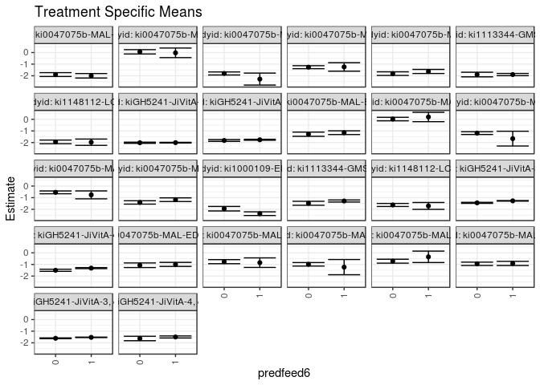

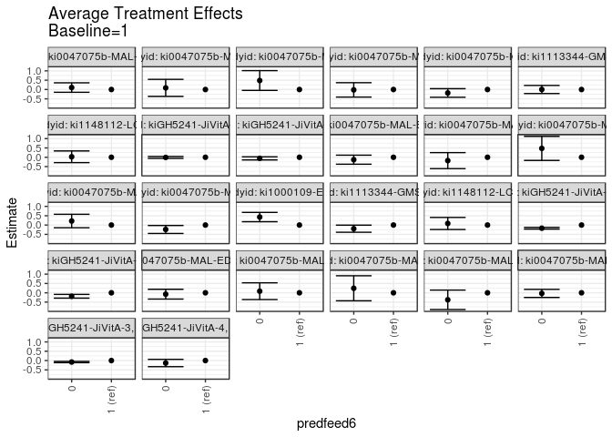

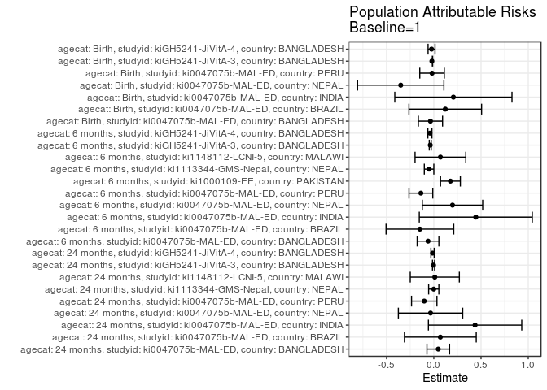

## Results Table

### Parameter: TSM

| agecat | studyid | country | intervention_level | baseline_level | estimate | ci_lower | ci_upper |
| --- | --- | --- | --- | --- | --- | --- | --- |
| Birth | ki0047075b-MAL-ED | BANGLADESH | 1 | NA | -0.9963257 | -1.1691111 | -0.8235403 |
| Birth | ki0047075b-MAL-ED | BANGLADESH | 0 | NA | -1.0700643 | -1.2679102 | -0.8722184 |
| Birth | ki0047075b-MAL-ED | BRAZIL | 1 | NA | -0.8476848 | -1.2585997 | -0.4367699 |
| Birth | ki0047075b-MAL-ED | BRAZIL | 0 | NA | -0.7612020 | -0.9359537 | -0.5864503 |
| Birth | ki0047075b-MAL-ED | INDIA | 1 | NA | -1.2323631 | -1.8857123 | -0.5790139 |
| Birth | ki0047075b-MAL-ED | INDIA | 0 | NA | -0.9904788 | -1.1395919 | -0.8413658 |
| Birth | ki0047075b-MAL-ED | NEPAL | 1 | NA | -0.3463124 | -0.8385834 | 0.1459587 |
| Birth | ki0047075b-MAL-ED | NEPAL | 0 | NA | -0.7217650 | -0.8903442 | -0.5531859 |
| Birth | ki0047075b-MAL-ED | PERU | 1 | NA | -0.9125266 | -1.0911264 | -0.7339268 |
| Birth | ki0047075b-MAL-ED | PERU | 0 | NA | -0.9452601 | -1.0875042 | -0.8030159 |
| Birth | kiGH5241-JiVitA-3 | BANGLADESH | 1 | NA | -1.5301170 | -1.5504409 | -1.5097930 |
| Birth | kiGH5241-JiVitA-3 | BANGLADESH | 0 | NA | -1.6093211 | -1.6416219 | -1.5770202 |
| Birth | kiGH5241-JiVitA-4 | BANGLADESH | 1 | NA | -1.4968713 | -1.5856124 | -1.4081302 |
| Birth | kiGH5241-JiVitA-4 | BANGLADESH | 0 | NA | -1.6285387 | -1.8199651 | -1.4371123 |
| 6 months | ki0047075b-MAL-ED | BANGLADESH | 1 | NA | -1.1527015 | -1.3135912 | -0.9918119 |
| 6 months | ki0047075b-MAL-ED | BANGLADESH | 0 | NA | -1.2821445 | -1.4627176 | -1.1015713 |
| 6 months | ki0047075b-MAL-ED | BRAZIL | 1 | NA | 0.1983082 | -0.2046580 | 0.6012744 |
| 6 months | ki0047075b-MAL-ED | BRAZIL | 0 | NA | 0.0191259 | -0.1330922 | 0.1713440 |
| 6 months | ki0047075b-MAL-ED | INDIA | 1 | NA | -1.6639296 | -2.2981474 | -1.0297118 |
| 6 months | ki0047075b-MAL-ED | INDIA | 0 | NA | -1.1878847 | -1.3065183 | -1.0692512 |
| 6 months | ki0047075b-MAL-ED | NEPAL | 1 | NA | -0.7576194 | -1.0985675 | -0.4166713 |
| 6 months | ki0047075b-MAL-ED | NEPAL | 0 | NA | -0.5422354 | -0.6624371 | -0.4220336 |
| 6 months | ki0047075b-MAL-ED | PERU | 1 | NA | -1.1725379 | -1.3303265 | -1.0147493 |
| 6 months | ki0047075b-MAL-ED | PERU | 0 | NA | -1.4097840 | -1.5537306 | -1.2658375 |
| 6 months | ki1000109-EE | PAKISTAN | 1 | NA | -2.3765132 | -2.5352908 | -2.2177356 |
| 6 months | ki1000109-EE | PAKISTAN | 0 | NA | -1.9478448 | -2.1414020 | -1.7542876 |
| 6 months | ki1113344-GMS-Nepal | NEPAL | 1 | NA | -1.2850710 | -1.3740102 | -1.1961319 |
| 6 months | ki1113344-GMS-Nepal | NEPAL | 0 | NA | -1.4812853 | -1.6501122 | -1.3124583 |
| 6 months | ki1148112-LCNI-5 | MALAWI | 1 | NA | -1.7096361 | -2.0052091 | -1.4140632 |
| 6 months | ki1148112-LCNI-5 | MALAWI | 0 | NA | -1.6252654 | -1.7559799 | -1.4945510 |
| 6 months | kiGH5241-JiVitA-3 | BANGLADESH | 1 | NA | -1.2727631 | -1.2977881 | -1.2477381 |
| 6 months | kiGH5241-JiVitA-3 | BANGLADESH | 0 | NA | -1.4431766 | -1.4882465 | -1.3981066 |
| 6 months | kiGH5241-JiVitA-4 | BANGLADESH | 1 | NA | -1.3160860 | -1.3579088 | -1.2742631 |
| 6 months | kiGH5241-JiVitA-4 | BANGLADESH | 0 | NA | -1.5021906 | -1.5944919 | -1.4098893 |
| 24 months | ki0047075b-MAL-ED | BANGLADESH | 1 | NA | -2.0003241 | -2.1921584 | -1.8084898 |
| 24 months | ki0047075b-MAL-ED | BANGLADESH | 0 | NA | -1.8958704 | -2.0613202 | -1.7304206 |
| 24 months | ki0047075b-MAL-ED | BRAZIL | 1 | NA | -0.0273834 | -0.4391397 | 0.3843728 |
| 24 months | ki0047075b-MAL-ED | BRAZIL | 0 | NA | 0.0608094 | -0.1255579 | 0.2471767 |
| 24 months | ki0047075b-MAL-ED | INDIA | 1 | NA | -2.2835292 | -2.7988866 | -1.7681718 |
| 24 months | ki0047075b-MAL-ED | INDIA | 0 | NA | -1.8005580 | -1.9299456 | -1.6711703 |
| 24 months | ki0047075b-MAL-ED | NEPAL | 1 | NA | -1.2398844 | -1.6034609 | -0.8763080 |
| 24 months | ki0047075b-MAL-ED | NEPAL | 0 | NA | -1.2604936 | -1.3893051 | -1.1316820 |
| 24 months | ki0047075b-MAL-ED | PERU | 1 | NA | -1.6280090 | -1.8043582 | -1.4516598 |
| 24 months | ki0047075b-MAL-ED | PERU | 0 | NA | -1.8137055 | -1.9696565 | -1.6577546 |
| 24 months | ki1113344-GMS-Nepal | NEPAL | 1 | NA | -1.8944389 | -1.9889097 | -1.7999681 |
| 24 months | ki1113344-GMS-Nepal | NEPAL | 0 | NA | -1.8928781 | -2.0900971 | -1.6956591 |
| 24 months | ki1148112-LCNI-5 | MALAWI | 1 | NA | -1.9710433 | -2.2423964 | -1.6996901 |
| 24 months | ki1148112-LCNI-5 | MALAWI | 0 | NA | -1.9444859 | -2.1008152 | -1.7881567 |
| 24 months | kiGH5241-JiVitA-3 | BANGLADESH | 1 | NA | -2.0093527 | -2.0385625 | -1.9801430 |
| 24 months | kiGH5241-JiVitA-3 | BANGLADESH | 0 | NA | -2.0172275 | -2.0680942 | -1.9663607 |
| 24 months | kiGH5241-JiVitA-4 | BANGLADESH | 1 | NA | -1.7628738 | -1.8046577 | -1.7210898 |
| 24 months | kiGH5241-JiVitA-4 | BANGLADESH | 0 | NA | -1.8215703 | -1.8995110 | -1.7436296 |

### Parameter: E(Y)

| agecat | studyid | country | intervention_level | baseline_level | estimate | ci_lower | ci_upper |
| --- | --- | --- | --- | --- | --- | --- | --- |
| Birth | ki0047075b-MAL-ED | BANGLADESH | NA | NA | -1.0317316 | -1.1618799 | -0.9015833 |
| Birth | ki0047075b-MAL-ED | BRAZIL | NA | NA | -0.7263429 | -0.8876385 | -0.5650472 |
| Birth | ki0047075b-MAL-ED | INDIA | NA | NA | -1.0250526 | -1.1724135 | -0.8776918 |
| Birth | ki0047075b-MAL-ED | NEPAL | NA | NA | -0.6964706 | -0.8552823 | -0.5376589 |
| Birth | ki0047075b-MAL-ED | PERU | NA | NA | -0.9311719 | -1.0458986 | -0.8164451 |
| Birth | kiGH5241-JiVitA-3 | BANGLADESH | NA | NA | -1.5502914 | -1.5696478 | -1.5309349 |
| Birth | kiGH5241-JiVitA-4 | BANGLADESH | NA | NA | -1.5207432 | -1.6058630 | -1.4356233 |
| 6 months | ki0047075b-MAL-ED | BANGLADESH | NA | NA | -1.2140355 | -1.3320337 | -1.0960372 |
| 6 months | ki0047075b-MAL-ED | BRAZIL | NA | NA | 0.0510207 | -0.0930194 | 0.1950608 |
| 6 months | ki0047075b-MAL-ED | INDIA | NA | NA | -1.2193606 | -1.3390323 | -1.0996890 |
| 6 months | ki0047075b-MAL-ED | NEPAL | NA | NA | -0.5595745 | -0.6727496 | -0.4463993 |
| 6 months | ki0047075b-MAL-ED | PERU | NA | NA | -1.3092999 | -1.4165606 | -1.2020392 |
| 6 months | ki1000109-EE | PAKISTAN | NA | NA | -2.2004704 | -2.3234073 | -2.0775336 |
| 6 months | ki1113344-GMS-Nepal | NEPAL | NA | NA | -1.3352045 | -1.4146382 | -1.2557708 |
| 6 months | ki1148112-LCNI-5 | MALAWI | NA | NA | -1.6395956 | -1.7592633 | -1.5199278 |
| 6 months | kiGH5241-JiVitA-3 | BANGLADESH | NA | NA | -1.3104400 | -1.3338132 | -1.2870668 |
| 6 months | kiGH5241-JiVitA-4 | BANGLADESH | NA | NA | -1.3574771 | -1.3964060 | -1.3185482 |
| 24 months | ki0047075b-MAL-ED | BANGLADESH | NA | NA | -1.9532775 | -2.0781247 | -1.8284303 |
| 24 months | ki0047075b-MAL-ED | BRAZIL | NA | NA | 0.0418343 | -0.1253834 | 0.2090521 |
| 24 months | ki0047075b-MAL-ED | INDIA | NA | NA | -1.8466071 | -1.9736347 | -1.7195796 |
| 24 months | ki0047075b-MAL-ED | NEPAL | NA | NA | -1.2744493 | -1.3952297 | -1.1536689 |
| 24 months | ki0047075b-MAL-ED | PERU | NA | NA | -1.7294949 | -1.8488722 | -1.6101177 |
| 24 months | ki1113344-GMS-Nepal | NEPAL | NA | NA | -1.8951389 | -1.9810871 | -1.8091907 |
| 24 months | ki1148112-LCNI-5 | MALAWI | NA | NA | -1.9605820 | -2.1001715 | -1.8209925 |
| 24 months | kiGH5241-JiVitA-3 | BANGLADESH | NA | NA | -2.0122091 | -2.0399540 | -1.9844641 |
| 24 months | kiGH5241-JiVitA-4 | BANGLADESH | NA | NA | -1.7762003 | -1.8148628 | -1.7375378 |

### Parameter: ATE

| agecat | studyid | country | intervention_level | baseline_level | estimate | ci_lower | ci_upper |
| --- | --- | --- | --- | --- | --- | --- | --- |
| Birth | ki0047075b-MAL-ED | BANGLADESH | 1 | 1 | 0.0000000 | 0.0000000 | 0.0000000 |
| Birth | ki0047075b-MAL-ED | BANGLADESH | 0 | 1 | -0.0737386 | -0.3371270 | 0.1896498 |
| Birth | ki0047075b-MAL-ED | BRAZIL | 1 | 1 | 0.0000000 | 0.0000000 | 0.0000000 |
| Birth | ki0047075b-MAL-ED | BRAZIL | 0 | 1 | 0.0864828 | -0.3634463 | 0.5364119 |
| Birth | ki0047075b-MAL-ED | INDIA | 1 | 1 | 0.0000000 | 0.0000000 | 0.0000000 |
| Birth | ki0047075b-MAL-ED | INDIA | 0 | 1 | 0.2418843 | -0.4293307 | 0.9130992 |
| Birth | ki0047075b-MAL-ED | NEPAL | 1 | 1 | 0.0000000 | 0.0000000 | 0.0000000 |
| Birth | ki0047075b-MAL-ED | NEPAL | 0 | 1 | -0.3754527 | -0.8966737 | 0.1457684 |
| Birth | ki0047075b-MAL-ED | PERU | 1 | 1 | 0.0000000 | 0.0000000 | 0.0000000 |
| Birth | ki0047075b-MAL-ED | PERU | 0 | 1 | -0.0327335 | -0.2504005 | 0.1849335 |
| Birth | kiGH5241-JiVitA-3 | BANGLADESH | 1 | 1 | 0.0000000 | 0.0000000 | 0.0000000 |
| Birth | kiGH5241-JiVitA-3 | BANGLADESH | 0 | 1 | -0.0792041 | -0.1116318 | -0.0467764 |
| Birth | kiGH5241-JiVitA-4 | BANGLADESH | 1 | 1 | 0.0000000 | 0.0000000 | 0.0000000 |
| Birth | kiGH5241-JiVitA-4 | BANGLADESH | 0 | 1 | -0.1316674 | -0.3291505 | 0.0658157 |
| 6 months | ki0047075b-MAL-ED | BANGLADESH | 1 | 1 | 0.0000000 | 0.0000000 | 0.0000000 |
| 6 months | ki0047075b-MAL-ED | BANGLADESH | 0 | 1 | -0.1294429 | -0.3717333 | 0.1128475 |
| 6 months | ki0047075b-MAL-ED | BRAZIL | 1 | 1 | 0.0000000 | 0.0000000 | 0.0000000 |
| 6 months | ki0047075b-MAL-ED | BRAZIL | 0 | 1 | -0.1791823 | -0.6087039 | 0.2503394 |
| 6 months | ki0047075b-MAL-ED | INDIA | 1 | 1 | 0.0000000 | 0.0000000 | 0.0000000 |
| 6 months | ki0047075b-MAL-ED | INDIA | 0 | 1 | 0.4760449 | -0.1687340 | 1.1208239 |
| 6 months | ki0047075b-MAL-ED | NEPAL | 1 | 1 | 0.0000000 | 0.0000000 | 0.0000000 |
| 6 months | ki0047075b-MAL-ED | NEPAL | 0 | 1 | 0.2153840 | -0.1466512 | 0.5774193 |
| 6 months | ki0047075b-MAL-ED | PERU | 1 | 1 | 0.0000000 | 0.0000000 | 0.0000000 |
| 6 months | ki0047075b-MAL-ED | PERU | 0 | 1 | -0.2372461 | -0.4512027 | -0.0232895 |
| 6 months | ki1000109-EE | PAKISTAN | 1 | 1 | 0.0000000 | 0.0000000 | 0.0000000 |
| 6 months | ki1000109-EE | PAKISTAN | 0 | 1 | 0.4286684 | 0.1785944 | 0.6787423 |
| 6 months | ki1113344-GMS-Nepal | NEPAL | 1 | 1 | 0.0000000 | 0.0000000 | 0.0000000 |
| 6 months | ki1113344-GMS-Nepal | NEPAL | 0 | 1 | -0.1962143 | -0.3867721 | -0.0056565 |
| 6 months | ki1148112-LCNI-5 | MALAWI | 1 | 1 | 0.0000000 | 0.0000000 | 0.0000000 |
| 6 months | ki1148112-LCNI-5 | MALAWI | 0 | 1 | 0.0843707 | -0.2390855 | 0.4078268 |
| 6 months | kiGH5241-JiVitA-3 | BANGLADESH | 1 | 1 | 0.0000000 | 0.0000000 | 0.0000000 |
| 6 months | kiGH5241-JiVitA-3 | BANGLADESH | 0 | 1 | -0.1704134 | -0.2172296 | -0.1235973 |
| 6 months | kiGH5241-JiVitA-4 | BANGLADESH | 1 | 1 | 0.0000000 | 0.0000000 | 0.0000000 |
| 6 months | kiGH5241-JiVitA-4 | BANGLADESH | 0 | 1 | -0.1861046 | -0.2856511 | -0.0865581 |
| 24 months | ki0047075b-MAL-ED | BANGLADESH | 1 | 1 | 0.0000000 | 0.0000000 | 0.0000000 |
| 24 months | ki0047075b-MAL-ED | BANGLADESH | 0 | 1 | 0.1044537 | -0.1498091 | 0.3587165 |
| 24 months | ki0047075b-MAL-ED | BRAZIL | 1 | 1 | 0.0000000 | 0.0000000 | 0.0000000 |
| 24 months | ki0047075b-MAL-ED | BRAZIL | 0 | 1 | 0.0881929 | -0.3684430 | 0.5448287 |
| 24 months | ki0047075b-MAL-ED | INDIA | 1 | 1 | 0.0000000 | 0.0000000 | 0.0000000 |
| 24 months | ki0047075b-MAL-ED | INDIA | 0 | 1 | 0.4829712 | -0.0480064 | 1.0139489 |
| 24 months | ki0047075b-MAL-ED | NEPAL | 1 | 1 | 0.0000000 | 0.0000000 | 0.0000000 |
| 24 months | ki0047075b-MAL-ED | NEPAL | 0 | 1 | -0.0206091 | -0.4067369 | 0.3655187 |
| 24 months | ki0047075b-MAL-ED | PERU | 1 | 1 | 0.0000000 | 0.0000000 | 0.0000000 |
| 24 months | ki0047075b-MAL-ED | PERU | 0 | 1 | -0.1856966 | -0.4160705 | 0.0446774 |
| 24 months | ki1113344-GMS-Nepal | NEPAL | 1 | 1 | 0.0000000 | 0.0000000 | 0.0000000 |
| 24 months | ki1113344-GMS-Nepal | NEPAL | 0 | 1 | 0.0015608 | -0.2171126 | 0.2202343 |
| 24 months | ki1148112-LCNI-5 | MALAWI | 1 | 1 | 0.0000000 | 0.0000000 | 0.0000000 |
| 24 months | ki1148112-LCNI-5 | MALAWI | 0 | 1 | 0.0265573 | -0.2867022 | 0.3398168 |
| 24 months | kiGH5241-JiVitA-3 | BANGLADESH | 1 | 1 | 0.0000000 | 0.0000000 | 0.0000000 |
| 24 months | kiGH5241-JiVitA-3 | BANGLADESH | 0 | 1 | -0.0078747 | -0.0595233 | 0.0437738 |
| 24 months | kiGH5241-JiVitA-4 | BANGLADESH | 1 | 1 | 0.0000000 | 0.0000000 | 0.0000000 |
| 24 months | kiGH5241-JiVitA-4 | BANGLADESH | 0 | 1 | -0.0586966 | -0.1417767 | 0.0243836 |

### Parameter: PAR

| agecat | studyid | country | intervention_level | baseline_level | estimate | ci_lower | ci_upper |
| --- | --- | --- | --- | --- | --- | --- | --- |
| Birth | ki0047075b-MAL-ED | BANGLADESH | 1 | NA | -0.0354059 | -0.1635020 | 0.0926902 |
| Birth | ki0047075b-MAL-ED | BRAZIL | 1 | NA | 0.1213419 | -0.2631993 | 0.5058831 |
| Birth | ki0047075b-MAL-ED | INDIA | 1 | NA | 0.2073105 | -0.4131390 | 0.8277599 |
| Birth | ki0047075b-MAL-ED | NEPAL | 1 | NA | -0.3501582 | -0.8073085 | 0.1069920 |
| Birth | ki0047075b-MAL-ED | PERU | 1 | NA | -0.0186453 | -0.1485426 | 0.1112520 |
| Birth | kiGH5241-JiVitA-3 | BANGLADESH | 1 | NA | -0.0201744 | -0.0278407 | -0.0125082 |
| Birth | kiGH5241-JiVitA-4 | BANGLADESH | 1 | NA | -0.0238718 | -0.0607130 | 0.0129694 |
| 6 months | ki0047075b-MAL-ED | BANGLADESH | 1 | NA | -0.0613339 | -0.1763146 | 0.0536467 |
| 6 months | ki0047075b-MAL-ED | BRAZIL | 1 | NA | -0.1472874 | -0.5056690 | 0.2110941 |
| 6 months | ki0047075b-MAL-ED | INDIA | 1 | NA | 0.4445690 | -0.1536638 | 1.0428018 |
| 6 months | ki0047075b-MAL-ED | NEPAL | 1 | NA | 0.1980450 | -0.1214563 | 0.5175462 |
| 6 months | ki0047075b-MAL-ED | PERU | 1 | NA | -0.1367620 | -0.2626760 | -0.0108480 |
| 6 months | ki1000109-EE | PAKISTAN | 1 | NA | 0.1760428 | 0.0711329 | 0.2809526 |
| 6 months | ki1113344-GMS-Nepal | NEPAL | 1 | NA | -0.0501335 | -0.1005671 | 0.0003002 |
| 6 months | ki1148112-LCNI-5 | MALAWI | 1 | NA | 0.0700405 | -0.1985627 | 0.3386437 |
| 6 months | kiGH5241-JiVitA-3 | BANGLADESH | 1 | NA | -0.0376769 | -0.0479712 | -0.0273825 |
| 6 months | kiGH5241-JiVitA-4 | BANGLADESH | 1 | NA | -0.0413911 | -0.0629066 | -0.0198757 |
| 24 months | ki0047075b-MAL-ED | BANGLADESH | 1 | NA | 0.0470466 | -0.0727676 | 0.1668609 |
| 24 months | ki0047075b-MAL-ED | BRAZIL | 1 | NA | 0.0692178 | -0.3109158 | 0.4493514 |
| 24 months | ki0047075b-MAL-ED | INDIA | 1 | NA | 0.4369221 | -0.0572170 | 0.9310611 |
| 24 months | ki0047075b-MAL-ED | NEPAL | 1 | NA | -0.0345649 | -0.3753041 | 0.3061742 |
| 24 months | ki0047075b-MAL-ED | PERU | 1 | NA | -0.1014860 | -0.2359571 | 0.0329851 |
| 24 months | ki1113344-GMS-Nepal | NEPAL | 1 | NA | -0.0007000 | -0.0547439 | 0.0533440 |
| 24 months | ki1148112-LCNI-5 | MALAWI | 1 | NA | 0.0104612 | -0.2494230 | 0.2703454 |
| 24 months | kiGH5241-JiVitA-3 | BANGLADESH | 1 | NA | -0.0028564 | -0.0141629 | 0.0084502 |
| 24 months | kiGH5241-JiVitA-4 | BANGLADESH | 1 | NA | -0.0133265 | -0.0307761 | 0.0041230 |